# Societal Institutions | Opinions and Behaviors: Marriage

# Introduction

There is no dearth of research on American’s changing attitudes towards marriage, its primacy as a way of life, and its exclusivity. Approximately four-in-ten Americans say that the present institution of marriage is becoming obsolete (Taylor 2010). According to the same Pew Research 2010 study, 72% of all adults in America were married in 1960. By 2008, this percentage had dropped to 52%. From this apparent decline in marriage, Americans are slowly becoming more accepting of open relationships, consensual non-manogamy (CNG) practices, and the like. Nearly half of the population of Americans would consider an open relationship, though fewer than 4% actually claim to be in one (Avvo 2017). Notwithstanding, nearly 22% of married men and 14% of married women admit to having an affair at least once during their marriages, with or without the spousal concent (Johnson et al. 2017).

## Research Questions

This observational study examines the nature opinion with respect to (w.r.t.) extra-marital conduct, and the degree to which such opinions have or have not evolved since the year 2000, via four research questions.

**Research Question 1:** To what degree have opinions changed since the year 2000 by age group?  
* Dependent Variable: Opinion w.r.t. extra-marital conduct  
* Explanatory Variable: Age group  
* Controlling Variable: Period, i.e., years prior to and since 2000

**Research Question 2:** To what degree have opinions changed since the year 2000 by gender?  
* Dependent Variable: Opinion w.r.t. extra-marital conduct  
* Explanatory Variable: Gender  
* Controlling Variable: Period, i.e., years prior to and since 2000

**Research Question 3:** To what degree have opinions changed since the year 2000 by highest education level achieved?  
* Dependent Variable: Opinion w.r.t. extra-marital conduct  
* Explanatory Variable: Highest education level achieved  
* Controlling Variable: Period, i.e., years prior to and since 2000

**Research Question 4:** To what degree have opinions changed since the year 2000 by region?  
* Dependent Variable: Opinion w.r.t. extra-marital conduct  
* Explanatory Variable: Region  
* Controlling Variable: Period, i.e., years prior to and since 2000

## Document Organization

The **methods** section describes the data, the sampling techniques, data preprocessing, and introduces the methods, descriptive and inferential techniques used in the analyses. Hypotheses are offered, analyzed and tested in the **results** section. The **discussion** section describes the significance of the findings vis-a-vis currently available research. Lastly, the **conclusion** synthesizes the key points.

# Methods

## Data

The General Social Survey (GSS), a project of the NORC at the University of Chicago, provided the data upon which this report is based. Formerly known as the National Opinion Research Center, “NORC at the University of Chicago is an objective non-partisan research institution that delivers reliable data and rigorous analysis to guide critical programmatic, business, and policy decisions” (NORC 2017). Principally funded by the National Science Foundation, the GSS has been monitoring evolution, complexity opinions, behaviors, and attributes of American society since 1972. Targeting the adult population, age 18 and over in the United, the data covers a diverse range of issues including national spending priorities, marijuana use, crime and punishment, race relations, quality of life, confidence in institutions, and sexual behavior.

### Data Sampling Strategy

The GSS employed a multi-stage area full probability sampling strategy.

At the first stage, NORC employed the Standard Metropolitan Statistical Areas (SMSAs) or non-metropolitan counties selected in NORC’s Master Sample, as the Primary Sampling Unit (PSU). These were further subdvided into three categories. Category 1, representing 56% of the US population, comprised of the nations largest metropolitan areas or Consolidated Statistical Areas (CSAs) with a population of at least 1,543,728 (0.5 percent of the 2010 Census U.S. population). The second category, covering 35% of the US population, included Core Based Statistical Areas and CSAs with at least 8 tracts that are predominantly street-style addresses. The third category spanned 9% of the US population and consisted of small counties with at most 8 tracts. Minimum size for tracts were defined as 300 respondents.

Similarly, the second stage sampling was conducted in three categories. Category 1 comprised 216 type A tracts (city addresses) and 8 block-groups within type B (rural) tracts. Category 2, consisted of 8 segments per first-stage selection resulted in 480 segments in the 2010 National Sample Design, but GSS used only 120 of them. For category 3 first-stage selections, the 2010 National Sample Design only selected 5 segments per first-stage selection, but GSS used 4 and one half of them for a total of 56 segments.

The sampling strategy employed by GSS was designed to give each household an equal probability of being included in the sample. For each household selected, sampling procedures were undertaken to ensure that each individual in that household had an equal probability of being interviewed.

### Data Sampling Bias

The GSS samples closely resemble distributions reported in the Census and other authoritative sources. However, survey non-response, sampling variation, and various other factors have introduced potential sources of bias and resulted in variance from Census distributions on some variables. For instance all full-probability samples under-represent males and block quota samples under-represented men in full-time employment. Weights were designed (and should be employed when using GSS 2004 or later), to assure proper representation of non-response sub-samples, and other factors. For a full discussion of distributional variation due to non-response, one should refer to the GSS Methodological Reports in the help and resources section at https://gssdataexplorer.norc.org/,

This full probability design was acknowledged by the National Science Foundation to be superior to simple random sampling, and **generalizable** to the population of adult citizens in America. Consisting of over 60,000 individual responses, spanning over 40 years, the GSS data remains one of the nations treasures, providing data for inference about American society to researchers, academics, students, politicians, and opinion makers. Yet, as respondents were randomly selected (not assigned), one is careful to limit inferences to **association, and not causation.** That said, the extent to which results of a research question can be generalized to the population will require that the inference conditions are met, specifically the proportion success/failure condition. As such, the question of “generalizeability” will need to be re-addressed independently for each research question.

### Data Variables

The following table lists the variables extracted from the GSS data.

Table 1: GSS Variables

| Variable | Description | Type | Subtype | Source |
| --- | --- | --- | --- | --- |
| YEAR | GSS Year for This Respondent | Categorical | Discrete | GSS |
| AGE | Age of Respondent | Quantitative | Discrete | GSS |
| SEX | Gender of Respondent | Categorical | Discrete | GSS |
| XMARSEX | Opinion w.r.t. Extra-Marital Sex | Categorical | Discrete | GSS |
| EDUC | Highest Education Level Achieved | Categorical | Discrete | GSS |
| REGION | Region of Interview | Categorical | Discrete | GSS |

### Data Preprocessing

The GSS variables were extracted for years 1972 thru 2016 and the following variables were created.

**Period**: Two factor variable  
* Prior to 2000: Period from 1972 through 1999 inclusive  
* Since 2000: Period from 2000 through 2016  
**Age Group**: Four factor variable  
* 18-24 * 25-44  
* 45-64 * 65+  
**Opinion**: Two factor variable:  
* Traditional: Always wrong and almost always wrong  
* Non-Traditional: Sometimes wrong and not wrong at all  
**Region**: Five factor variable:  
* Northeast: Comprised of responses from the New England and Mid Atlantic regions  
* MidWest: Comprised of responses from the East Central and West Central regions  
* South: Consisting of responses from the South Atlantic and East and West South Central regions  
* Mountain  
* Pacific  
**Education**: Five factor variable:  
* High School: Education years 0 thru 12  
* Community College: Education years 13 thru 14  
* UnderGraduate: Education years 15 thru 16  
* Graduate: Education years 17 thru 18  
* Post-Graduate: Education years 19 thru 20

Responses with “NAs”, “Don’t Know”, and other non-response values for the GSS variables in scope, were filtered from the data set.

## Data Analysis

The data analysis outlined in the results section begins with a univariate exploratory data analysis of each study variable. Frequencies and proportions of responses for each categorical value are presented as well as confidence intervals for the population proportions at each categorical variable level.

Having established the univariate descriptive and inferential statistics, each research question was explored using the following hypothesis testing approach:  
1. State Hypotheses  
2. Check Parametric Inference Conditions  
3. Select appropriate statistical method / test statistic  
4. Compute the p-value, the probability of observing the data given the null hypothesis  
5. Interpret and report results.

### State Hypotheses

The research questions were aimed at discovering the extent to which opinions have changed over time. As such, the two-sided hypotheses in this study take the following form:  
$H_0$ $p_1 - p_2 = 0$  
$H_a$ $p_1 - p_2 \neq 0$

where:  
$p_1$ is a proportion of interest for years prior to 2000  
$p_2$ is a proportion of interest for years since 2000

### Inference Conditions

Statistical inferences were derived from parametric statistics and the central limit theoreom, whereby the former assumes that sample data comes from a population distribution with a fixed set of parameters, and the later assumes that the distribution is normal and that the parameters are $N(\mu, \sigma^2)$, where $\mu$ is the population proportion parameter $\hat{p}$ and $\sigma^2$ is the variation of of the population proportion parameter. We can assume that the sample comes from a normally distributed population if:

1. **Independence:** The sample observations must be independent. Since all samples were obtained through random sampling, independence was assumed for all statistical tests.
2. **Success/Failure:** For one proportion inference, there must be a minimum of ten successes and failures for dichotomous variables. For comparison of two proportions, there must be a minimum of five counts in the **expected** frequency contingency table at each cell. Concretely, there must be at least five counts for each response/explanatory/controlling variable combination.
3. **Sample Size:** The sample size must be less than 10% of the population, if drawn without replacement. According to 2010 census, the population of adults ag 18 and older exceeded 200 million. Since the GSS data contains less than 2 million observations, this sample size requirement was assumed for all statistical tests.

### Statistical Methods

Two types of statistical methods were used to evaluate the hypotheses statements:  
1. Two-proportion z-tests for hypotheses w.r.t. the difference in two proportions.  
2. Two-proportion z-tests for confidence intervals w.r.t. the difference in two proportions.

#### Two proportion z-test for hypothesis tests

To evaluate hypotheses w.r.t. the difference in two proportions, z-tests were conducted using the *pooled* proportions for the standard error calculation. Pooled proportions, $\hat{p}$, were calculated as follows:

$$\hat{p} = \frac{\hat{p_1}n_1 + \hat{p_2}n_2}{n_1 + n_2}$$
where:
$n1$ is the number of responses of interest prior to the year 2000
$n2$ is the number of responses of interest since the year 2000
$p1$ is the the proportion of responses of interest prior to the year 2000
$p2$ is the the proportion of responses of interest since the year 2000

Given the pooled proportion, the *pooled* standard error, $SE_{pooled}$, for the difference in proportions was calculated as follows:
$$SE_{pooled} = \sqrt{\frac{\hat{p}(1-\hat{p})}{n_1} + \frac{\hat{p}(1-\hat{p})}{n_2}}$$
where:
$\hat{p}$ is the pooled proortion calculated above
$n1$ is the number of responses of interest prior to the year 2000
$n2$ is the number of responses of interest since the year 2000

Lastly, the z-statistic under the null hypothesis of equal proportions was calculated as follows:
$$Z = \frac{(\hat{p_1} - \hat{p_2}) - 0}{SE_{pooled}}$$
The z-statistic was used to calculate a p-value by comparing the value of the statistic for each random variable $X$ to a *standard normal* distribution ($X \sim N(\mu = 0, \sigma^2 = 1)$. The selected level of confidence for all statistical tests was 95% ($\alpha = 0.05$). If the p-value was less than or equal to $alpha$, the null hypothesis was rejected. Otherwise, the null hypothesis was not rejected. The p-value for a guassian distribution can be readily obtained by most statistical software packages and is computed as follows:
$$p(x;\mu, \sigma^2) = \frac{1}{\sqrt{2\pi} * \sigma} * exp(-\frac{(x-\mu)^2}{2\sigma^2})$$
where:
$x$ = random variable
$\mu$ = mean of random variable $x$
$\sigma$ = standard deviation of a random variable $x$

#### Two proportion z-test for confidence intervals

Z-tests were conducted to compute the confidence interval for the difference in two proportions. The 95% confidence intervals for the differences in two proportions were computed as follows:
$$C = (\hat{p_1} - \hat{p_2}) \pm Z^* * SE$$
where:
$\hat{p_1}$ is the the proportion of responses of interest prior to the year 2000
$\hat{p_2}$ is the the proportion of responses of interest since the year 2000
$Z^*$ is the $z_{\alpha/2}$ critical value for a two sided z-distribution at a 95% confidence level $\approx 1.96$

The standard error $SE$ is computed as follows:
$$SE= \sqrt{\frac{\hat{p_1}(1-\hat{p_1})}{n_1} + \frac{\hat{p_2}(1-\hat{p_2})}{n_2}}$$
where:
$n1$ is the number of responses of interest prior to the year 2000
$n2$ is the number of responses of interest since the year 2000
$\hat{p_1}$ is the the proportion of responses of interest prior to the year 2000
$\hat{p_2}$ is the the proportion of responses of interest since the year 2000

#### Interpret and report results

**Confidence intervals** for the difference in proportions were also computed. If the confidence interval did not include zero difference, the null hypothesis was rejected.

**Relative risk** was also computed to characterize the direction and size of the difference of proportions.

## System and Environment

This analysis was implemented using the 64 bit version of the R Programming Language, version 3.4.1. (The R Foundation 2015) within the R. Studio Version 1.1.330 (Rstudio Team 2016) development environment on a Windows x64-based laptop powered by an Intel Core i7-3610QM CPU @ 2.30GHz, 2301 MHz processor with 4 Cores, 8 Logical Processors, and 16.0 GB of installed memory, running the Microsoft Windows 10 Home operating system, version 10.0.14393 Build 14393. Report writing and generation packages included knitr (Xie 2013), and kfigr (Koohafkan 2015). Data management functionality was provided by the dplyr [Wickham2015a], reshape2 (Rcpp 2016), xtable (Dahl and Scott 2016) and data table (Dowle 2016) packages. Graphics and data visualization were powered by the ggplot2 (Wickham 2016), gridExtra (Baptiste Auguie 2016), and the stargazer (Hlavac et al. 2015) packages. The inference (A. Vinh Nguyen and Vinh Nguyen 2017) statistcal package provided functionality for extracting inferential values from a fitted model.

# Results

As a preliminary step, a univariate exploratory data analysis was undertaken for each variable in the study as described above.

## Exploratory Data Analysis

Using tables and barplots, each study variable was examined in terms of:  
* **N**: The counts for each level of the categorical variable  
* **Minimum N**: The minimum sample size required to ensure that the sample proportions were within a 5% margin of error (the confidence intervals) of the population proportions.  
* **Proportion**: The proportional responses at each level of each categorical variable  
* **Cumulative Proportions**: The cumulative proportions at each level of each categorical variable  
* **Confidence Interval**: The 95% confidence interval for the population proportion at each categorical level

Furthermore, the conditions for inference were checked in order to characterize the degree to which the samples were representative of the population proportions.

### Opinion

The following table provides the descriptive statistics for the Opinion variable.

Table 2: Descriptive Statistics for Opinion Variable

| Level | Minimum N | N | Proportion | Cumulative | Confidence Interval (95%) |
| --- | --- | --- | --- | --- | --- |
| Traditional | 142 | 33717 | 0.9 | 0.9 | [0.897, 0.903] |
| Non-Traditional | 142 | 3865 | 0.1 | 1.0 | [0.091, 0.109] |

As shown in Table 2 and graphically depicted in Figure 1, there were a total of 37,582 observations, with 33,717, and 3,865 traditional and non-traditional opinions, respectively. Of all respondents interviewed since 1972, 90% consider extra-marital conduct to be wrong or almost always wrong!

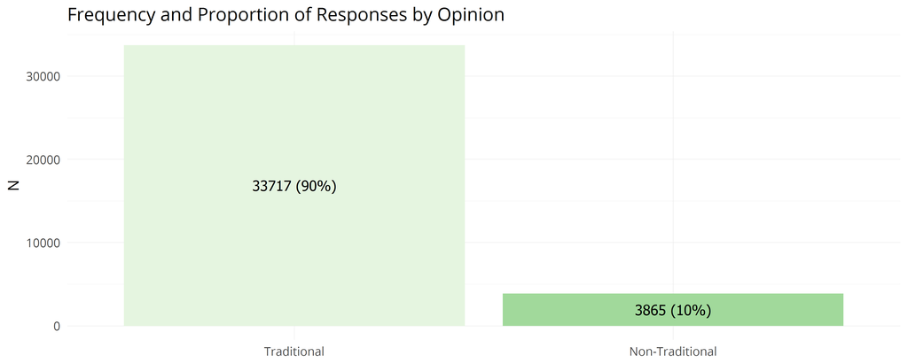

Figure 1: Frequency and Proportions for Opinion Variable

### Period

The following table provides the descriptive statistics for the period variable.

Table 3: Descriptive Statistics for Period Variable

| Level | Minimum N | N | Proportion | Cumulative | Confidence Interval (95%) |
| --- | --- | --- | --- | --- | --- |
| Prior to 2000 | 365 | 38116 | 0.61 | 0.61 | [0.605, 0.615] |
| Since 2000 | 365 | 24350 | 0.39 | 1.00 | [0.384, 0.396] |

As shown in Table 3 and graphically depicted in Figure 2, there were a total of 62,466 observations, with 38,116, and 24,350 observations for the years prior to 2000, and the years since 2000, respectively. Over 60% of responses were obtained prior to the year 2000.

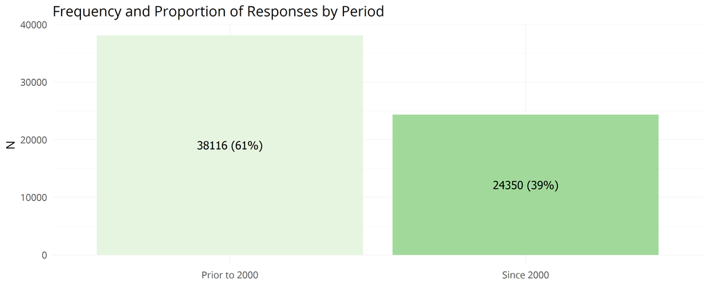

Figure 2: Frequency and Proportions for Period Variable

### Age Group

The following table provides the descriptive statistics for the Age Group variable.

Table 4: Descriptive Statistics for Age Group Variable

| Level | Minimum N | N | Proportion | Cumulative | Confidence Interval (95%) |
| --- | --- | --- | --- | --- | --- |
| 15-24 | 141 | 6337 | 0.10 | 0.10 | [0.093, 0.107] |
| 25-44 | 373 | 25846 | 0.42 | 0.52 | [0.414, 0.426] |
| 45-64 | 325 | 18959 | 0.30 | 0.82 | [0.293, 0.307] |
| 65+ | 225 | 11103 | 0.18 | 1.00 | [0.173, 0.187] |

As shown in Table 4 and graphically depicted in Figure 3, there were a total of 62,245 observations. Over 50% of responses were obtained from respondents below 45 years of age.

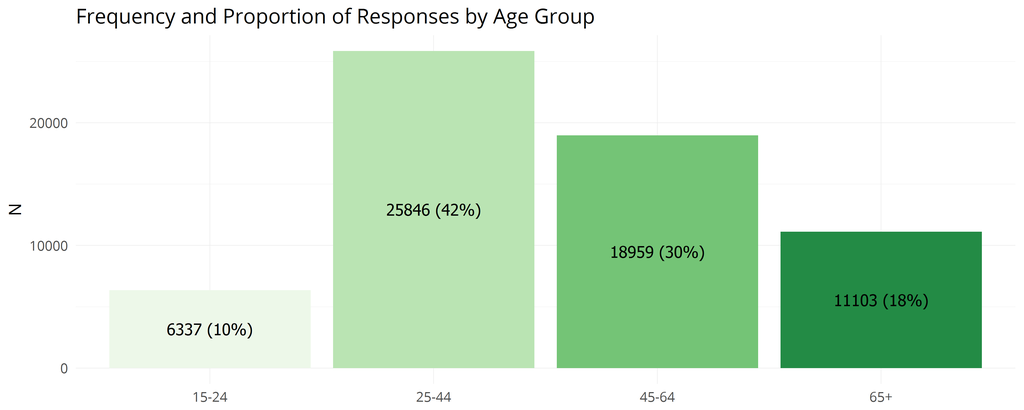

Figure 3: Frequency and Proportions for Age Group Variable

### Gender

The following table provides the descriptive statistics for the Gender variable.

Table 5: Descriptive Statistics for Gender Variable

| Level | Minimum N | N | Proportion | Cumulative | Confidence Interval (95%) |
| --- | --- | --- | --- | --- | --- |
| Male | 379 | 27562 | 0.44 | 0.44 | [0.434, 0.446] |
| Female | 379 | 34904 | 0.56 | 1.00 | [0.555, 0.565] |

As shown in Table 5 and graphically depicted in Figure 4, there were a total of 62,466 observations. The percentage of male and female respondents were 44 and 56, respectively.

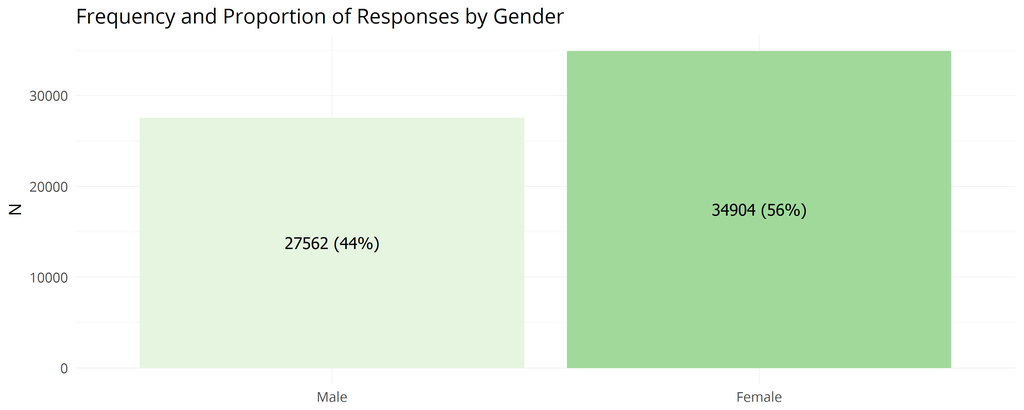

Figure 4: Frequency and Proportions for Gender Variable

### Education

The following table provides the descriptive statistics for the Education variable.

Table 6: Descriptive Statistics for Education Variable

| Level | Minimum N | N | Proportion | Cumulative | Confidence Interval (95%) |
| --- | --- | --- | --- | --- | --- |
| High School | 383 | 33183 | 0.53 | 0.53 | [0.525, 0.535] |
| Community College | 239 | 12024 | 0.19 | 0.72 | [0.183, 0.197] |
| UnderGraduate | 219 | 10708 | 0.17 | 0.89 | [0.163, 0.177] |
| Graduate | 95 | 4135 | 0.07 | 0.96 | [0.062, 0.078] |
| Post-Graduate | 53 | 2242 | 0.04 | 1.00 | [0.032, 0.048] |

As shown in Table 6 and graphically depicted in Figure 5, there were a total of 62,292 observations. High school graduates comprised over 50% of respondents. High school graduates with some college made up approximately 70% of the sample. Those with undergraduate, graduate, and post-graduage degrees represented 17%, 7%, and 4%, of the sample respectively.

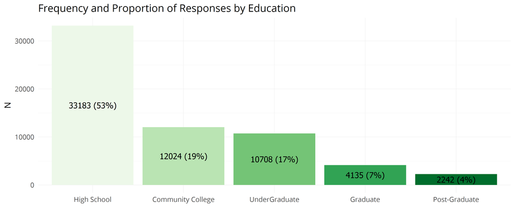

Figure 5: Frequency and Proportions for Education Variable

### Region

The following table provides the descriptive statistics for the Region variable.

Table 7: Descriptive Statistics for Region Variable

| Level | Minimum N | N | Proportion | Cumulative | Confidence Interval (95%) |
| --- | --- | --- | --- | --- | --- |
| Northeast | 239 | 12033 | 0.19 | 0.19 | [0.183, 0.197] |
| South | 351 | 22083 | 0.35 | 0.54 | [0.344, 0.356] |
| Midwest | 293 | 16061 | 0.26 | 0.80 | [0.253, 0.267] |
| Mountain | 90 | 3882 | 0.06 | 0.86 | [0.053, 0.067] |
| Pacific | 179 | 8407 | 0.13 | 0.99 | [0.123, 0.137] |

As shown in Table 7 and graphically depicted in Figure 6, there were a total of 62,466 observations. Over 50% of respondents resided in eastern and southeastern parts of the country, 26% in the Midwest and the rest in the western states.

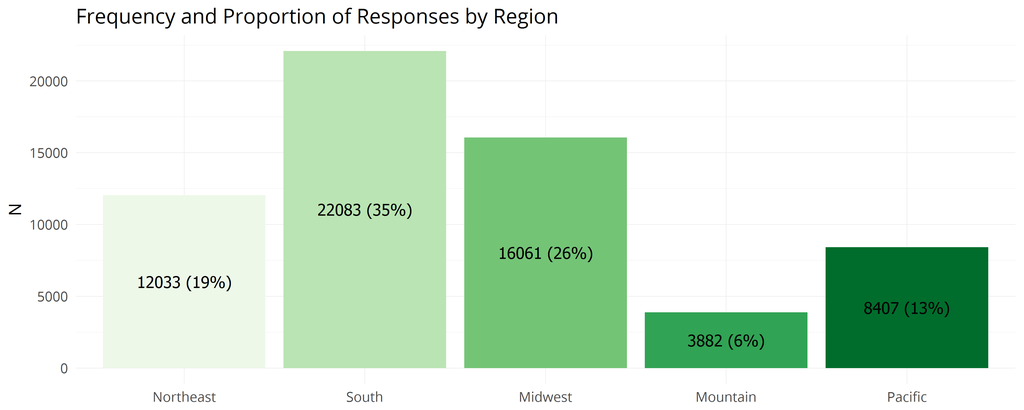

Figure 6: Frequency and Proportions for Region Variable

### Summary of Exploratory Data Analysis

All conditions of inference: independence, success/failure, and sample size, were met. Therefore, one can assume that the true population proportions were within a 5% margin of error from their corresponding sample proportion.

## Research Question 1: Evolution of opinion by age group

Here, the degree to which opinions w.r.t. extra-marital conduct have changed by age group was examined via the following research question.

> To what degree have opinions changed since the year 2000 by age group?

### Hypotheses

The following hypotheses were tested to discover the extent to which opinion has changed by age group, over the periods of the study. Generally stated, they are:  
$H_0$: $p_1 - p_2 = 0$  
$H_a$: $p_1 - p_2 \neq 0$

where:  
$p_1$ is the proportion of traditional opinion within an age group for years prior to 2000  
$p_2$ is the proportion of traditional opinion within an age group for years since 2000

The specific hypotheses for each age group are stated below.

### Inference Conditions

The inference conditions for a two-proportion hypothesis tests were examined as follows:

1. **Independence:** Each observation was subject to a stratified random sampling and so **independence** was assumed.
2. **Success/Failure:** Expected counts for each response/explanatory/controlling variable combination must be five or greater. As shown in Table 8, the expected counts exceed this minimum threshold.
3. **Sample Size:** As indicated in section the methods section, the sample size falls well below 10% of the U.S. adult population.

Table 8: Contingency table of expected counts of opinions by age group, controlling for period

|  |  | AgeGroup | 15-24 | 25-44 | 45-64 | 65+ |
| --- | --- | --- | --- | --- | --- | --- |
| Opinion | Period |  |  |  |  |  |
| Traditional | Prior to 2000 |  | 2262 | 8979 | 6564 | 3916 |
|  | Since 2000 |  | 1236 | 4909 | 3588 | 2141 |
| Non-Traditional | Prior to 2000 |  | 286 | 1135 | 830 | 495 |
|  | Since 2000 |  | 116 | 461 | 337 | 201 |

As such, the conditions for two-proportion z-tests were met.

### Test Results

#### Age Group 15-24

The following hypotheses were devised to ascertain the difference in proportion of traditional opinion w.r.t. extra-marital conduct for the age group 15-24 over the two periods of the study.  
$H_0$ $p_1 - p_2 = 0$  
$H_a$ $p_1 - p_2 \neq 0$  
where:  
$p_1$ is the proportion of traditional opinion in age group 15-24 for years prior to 2000  
$p_2$ is the proportion of traditional opinion in age group 15-24 for years since 2000

This was a 95% confidence, two-proportion z-test of the null hypothesis that the true population proportion of traditional opinion within the age group 15-24 population is equal for the periods prior to, and since, the year 2,000.

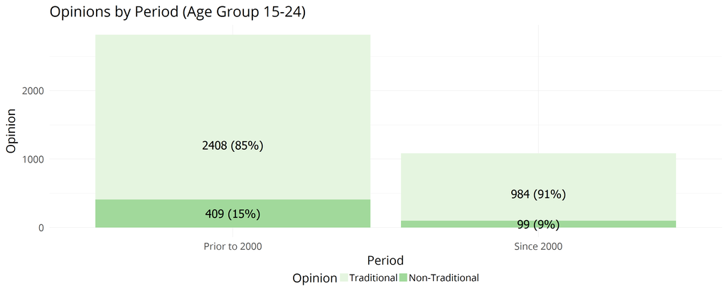

Figure 7: Observed opinions for age group 15-24 prior to and since the year 2000

As shown in Figure 7 and Table 9, the observed frequency of traditional opinion since 2,000 in the age group 15-24 was 984 out of a total of 1,083 observations, yielding a proportion equal to 0.91. The observed frequency of traditional opinion prior to 2,000 in the age group 15-24 population was 2,408 out of a total of 2,817 observations, yielding a proportion equal to 0.85. The difference in observed proportions of traditional opinion was 0.05, raising a z-score of 4.47. The probability of encountering a difference in proportions this extreme (p-value) is approximately 0.

Table 9: Two-proportion z-test of traditional opinion by period for age group 15-24

| Test | Groups | Scope | H0 | Ha | Alpha | p1 | p2 | Diff | zScore | pValue | CI | Decision |
| --- | --- | --- | --- | --- | --- | --- | --- | --- | --- | --- | --- | --- |
| Two-Sample Proportion Test | Prior to 2000/Since 2000 | Age Group 15-24 | H0: p1 = p2 | p1 <> p2 | 0.05 | 0.85 | 0.91 | 0.05 | 4.47 | 0 | [ -0.075 , -0.032 ] | Reject |

Therefore, the null hypothesis was rejected with, 95% confidence, in favor of the alternative hypothesis that the true population proportion of traditional opinion within the age group 15-24 population since 2,000 is not equal to the true population proportion of traditional opinion within the age group 15-24 population prior to 2,000. Moreover, one can conclude with 95% confidence, that a randomly selected person from the age group 15-24 population since 2,000 is 1.06 times as likely to hold traditional opinions than such a randomly selected person from the age group 15-24 population prior to 2,000.

#### Age Group 25-44

The following hypotheses were devised to ascertain the difference in proportion of traditional opinion w.r.t. extra-marital conduct for the age group 25-44 over the two periods of the study.  
$H_0$ $p_1 - p_2 = 0$  
$H_a$ $p_1 - p_2 \neq 0$  
where:  
$p_1$ is the proportion of traditional opinion in age group 25-44 for years prior to 2000  
$p_2$ is the proportion of traditional opinion in age group 25-44 for years since 2000

This was a 95% confidence, two-proportion z-test of the null hypothesis that the true population proportion of traditional opinion within the age group 25-45 population is equal for the periods prior to, and since, the year 2,000.

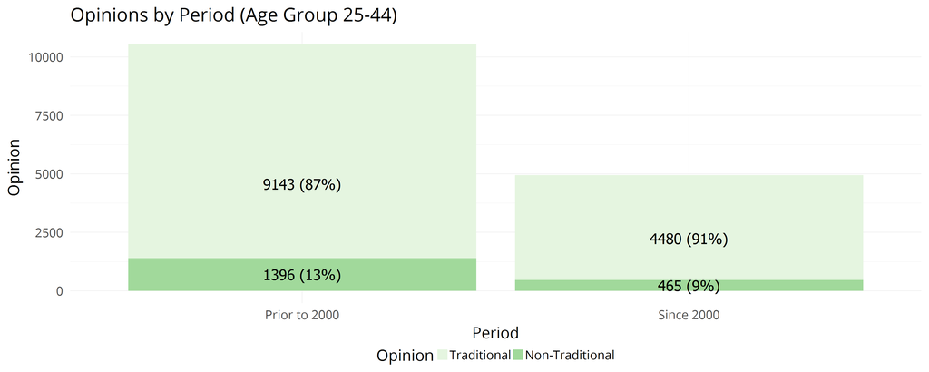

Figure 8: Observed opinions for age group 25-44 prior to and since the year 2000

As shown in Figure 8 and Table 10, the observed frequency of traditional opinion since 2,000 in the age group 25-45 was 4,480 out of a total of 4,945 observations, yielding a proportion equal to 0.91. The observed frequency of traditional opinion prior to 2,000 in the age group 25-45 population was 9,143 out of a total of 10,539 observations, yielding a proportion equal to 0.87. The difference in observed proportions of traditional opinion was 0.04, raising a z-score of 6.86. The probability of encountering a difference in proportions this extreme (p-value) is approximately 0.

Table 10: Two-proportion z-test of traditional opinion by period for age group 25-44

| Test | Groups | Scope | H0 | Ha | Alpha | p1 | p2 | Diff | zScore | pValue | CI | Decision |
| --- | --- | --- | --- | --- | --- | --- | --- | --- | --- | --- | --- | --- |
| Two-Sample Proportion Test | Prior to 2000/Since 2000 | Age Group 25-45 | H0: p1 = p2 | p1 <> p2 | 0.05 | 0.87 | 0.91 | 0.04 | 6.86 | 0 | [ -0.049 , -0.028 ] | Reject |

Therefore, the null hypothesis was rejected with, 95% confidence, in favor of the alternative hypothesis that the true population proportion of traditional opinion within the age group 25-45 population since 2,000 is not equal to the true population proportion of traditional opinion within the age group 25-45 population prior to 2,000. Moreover, one can conclude with 95% confidence, that a randomly selected person from the age group 25-45 population since 2,000 is 1.04 times as likely to hold traditional opinions than such a randomly selected person from the age group 25-45 population prior to 2,000.

#### Age Group 45-64

The following hypotheses were devised to ascertain the difference in proportion of traditional opinion w.r.t. extra-marital conduct for the age group 45-64 over the two periods of the study.  
$H_0$ $p_1 - p_2 = 0$  
$H_a$ $p_1 - p_2 \neq 0$  
where:  
$p_1$ is the proportion of traditional opinion in age group 45-64 for years prior to 2000  
$p_2$ is the proportion of traditional opinion in age group 45-64 for years since 2000

This was a 95% confidence, two-proportion z-test of the null hypothesis that the true population proportion of traditional opinion within the age group 45-65 population is equal for the periods prior to, and since, the year 2,000.

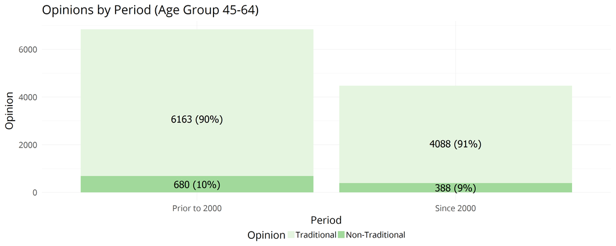

Figure 9: Observed opinions for age group 45-64 prior to and since the year 2000

Table 12: Two-proportion z-test of traditional opinion by period for age group 45-64

| Test | Groups | Scope | H0 | Ha | Alpha | p1 | p2 | Diff | zScore | pValue | CI | Decision |
| --- | --- | --- | --- | --- | --- | --- | --- | --- | --- | --- | --- | --- |
| Two-Sample Proportion Test | Prior to 2000/Since 2000 | Age Group 45-65 | H0: p1 = p2 | p1 <> p2 | 0.05 | 0.9 | 0.91 | 0.01 | 2.26 | 0.024 | [ -0.024 , -0.002 ] | Reject |

Therefore, the null hypothesis was rejected with, 95% confidence, in favor of the alternative hypothesis that the true population proportion of traditional opinion within the age group 45-65 population since 2,000 is not equal to the true population proportion of traditional opinion within the age group 45-65 population prior to 2,000. Moreover, one can conclude with 95% confidence, that a randomly selected person from the age group 45-65 population since 2,000 is 1.01 times as likely to hold traditional opinions than such a randomly selected person from the age group 45-65 population prior to 2,000.

#### Age Group 65+

The following hypotheses were devised to ascertain the difference in proportion of traditional opinion w.r.t. extra-marital conduct for the age group 65+ over the two periods of the study.  
$H_0$ $p_1 - p_2 = 0$  
$H_a$ $p_1 - p_2 \neq 0$  
where:  
$p_1$ is the proportion of traditional opinion in age group 65+ for years prior to 2000  
$p_2$ is the proportion of traditional opinion in age group 65+ for years since 2000

This was a 95% confidence, two-proportion z-test of the null hypothesis that the true population proportion of traditional opinion within the age group 65+ population is equal for the periods prior to, and since, the year 2,000.

As indicated in Table 13 and Table 13, the observed frequency of traditional opinion prior to 2,000 in the age group 65+ was 4,007 out of a total of 4,267 observations, yielding a proportion equal to 0.94. The observed frequency of traditional opinion since 2,000 in the age group 65+ population was 2,322 out of a total of 2,486 observations, yielding a proportion equal to 0.93. The difference in observed proportions of traditional opinion was 0.01, raising a z-score of 0.82. The probability of encountering a difference in proportions this extreme (p-value) is approximately 0.4,106.

Table 13: Two-proportion z-test of traditional opinion by period for age group 65+

| Test | Groups | Scope | H0 | Ha | Alpha | p1 | p2 | Diff | zScore | pValue | CI | Decision |
| --- | --- | --- | --- | --- | --- | --- | --- | --- | --- | --- | --- | --- |
| Two-Sample Proportion Test | Prior to 2000/Since 2000 | Age Group 65+ | H0: p1 = p2 | p1 <> p2 | 0.05 | 0.94 | 0.93 | 0.01 | 0.82 | 0.4106 | [ -0.007 , 0.017 ] | Fail to Reject |

Therefore, the null hypothesis was not rejected; consequently, one concludes, with 95% confidence, that the true proportion of traditional opinion among the age group 65+ population prior to and since the year 2,000 are equal. Further, the confidence interval for the difference in proportions includes zero, the null hypothesis value. As such, the null hypothesis is not rejected and both the hypothesis test and confidence interval methods agree.

## Research Question 2: Evolution of opinion by gender

Here, the degree to which opinions w.r.t. extra-marital conduct have changed by gender was examined via the following research question.

> To what degree have opinions changed since the year 2000 by gender?

### Hypotheses

The degree to which opinions have changed by gender was examined via the following hypotheses:  
$H_0$ $p_1 - p_2 = 0$  
$H_a$ $p_1 - p_2 \neq 0$

where:  
$p_1$ is the proportion of traditional opinion among those of a specific gender for years prior to 2000  
$p_2$ is the proportion of traditional opinion among those of a specific gender for years since 2000

The specific hypotheses by gender are stated below.

### Inference Conditions

The inference conditions for a two-proportion test for differences in the proportion of traditional opinion between the genders, were examined as follows:

Table 14: Contingency table of expected counts of opinions by gender, controlling for period

|  |  | Gender | Male | Female |
| --- | --- | --- | --- | --- |
| Opinion | Period |  |  |  |
| Traditional | Prior to 2000 |  | 9622 | 12182 |
|  | Since 2000 |  | 5257 | 6656 |
| Non-Traditional | Prior to 2000 |  | 1213 | 1535 |
|  | Since 2000 |  | 493 | 624 |

As such, the conditions for two-proportion z-tests were met.

### Test Results

#### Male Population

The following hypotheses were tested to discover the extent to which opinion has changed among men over the periods of the study.  
$H_0$ $p_1 - p_2 = 0$  
$H_a$ $p_1 - p_2 \neq 0$

where:  
$p_1$ is the proportion of traditional opinion among men for years prior to 2000  
$p_2$ is the proportion of traditional opinion among men for years since 2000

This was a 95% confidence, two-proportion z-test of the null hypothesis that the true population proportion of traditional opinion within the male population is equal for the periods prior to, and since, the year 2,000.

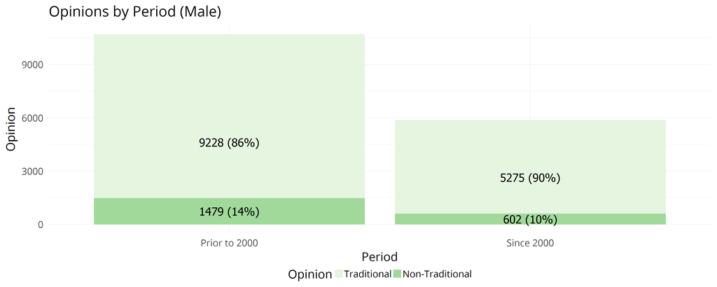

Figure 11: Observed Opinions among men prior to and since the year 2000

As indicated in Figure 11 and Table 15, the observed frequency of traditional opinion since 2,000 in the male was 5,275 out of a total of 5,877 observations, yielding a proportion equal to 0.9. The observed frequency of traditional opinion prior to 2,000 in the male population was 9,228 out of a total of 10,707 observations, yielding a proportion equal to 0.86. The difference in observed proportions of traditional opinion was 0.04, raising a z-score of 6.64. The probability of encountering a difference in proportions this extreme (p-value) is approximately 0.

Table 15: Two-proportion z-test of traditional opinion by period for male population

| Test | Groups | Scope | H0 | Ha | Alpha | p1 | p2 | Diff | zScore | pValue | CI | Decision |
| --- | --- | --- | --- | --- | --- | --- | --- | --- | --- | --- | --- | --- |
| Two-Sample Proportion Test | Prior to 2000/Since 2000 | Male | H0: p1 = p2 | p1 <> p2 | 0.05 | 0.86 | 0.9 | 0.04 | 6.64 | 0 | [ -0.046 , -0.026 ] | Reject |

Therefore, the null hypothesis was rejected with, 95% confidence, in favor of the alternative hypothesis that the true population proportion of traditional opinion within the male population since 2,000 is not equal to the true population proportion of traditional opinion within the male population prior to 2,000. Moreover, one can conclude with 95% confidence, that a randomly selected person from the male population since 2,000 is 1.04 times as likely to hold traditional opinions than such a randomly selected person from the male population prior to 2,000.

#### Female Population

The following hypotheses were tested to discover the extent to which opinion has changed among women over the periods of the study.  
$H_0$ $p_1 - p_2 = 0$  
$H_a$ $p_1 - p_2 \neq 0$

where:  
$p_1$ is the proportion of traditional opinion among women for years prior to 2000  
$p_2$ is the proportion of traditional opinion among women for years since 2000

This was a 95% confidence, two-proportion z-test of the null hypothesis that the true population proportion of traditional opinion within the female population is equal for the periods prior to, and since, the year 2,000.

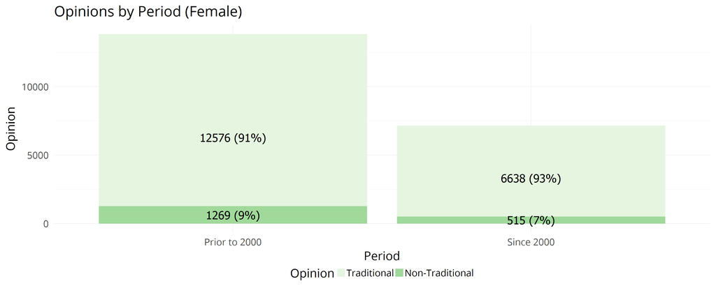

Figure 12: Observed opinions among women prior to and since the year 2000

As indicated in Figure 12 and Table 16, the observed frequency of traditional opinion since 2,000 in the female was 6,638 out of a total of 7,153 observations, yielding a proportion equal to 0.93. The observed frequency of traditional opinion prior to 2,000 in the female population was 12,576 out of a total of 13,845 observations, yielding a proportion equal to 0.91. The difference in observed proportions of traditional opinion was 0.02, raising a z-score of 4.84. The probability of encountering a difference in proportions this extreme (p-value) is approximately 0.

Table 16: Two-proportion z-test of traditional opinion by period for female population

| Test | Groups | Scope | H0 | Ha | Alpha | p1 | p2 | Diff | zScore | pValue | CI | Decision |
| --- | --- | --- | --- | --- | --- | --- | --- | --- | --- | --- | --- | --- |
| Two-Sample Proportion Test | Prior to 2000/Since 2000 | Female | H0: p1 = p2 | p1 <> p2 | 0.05 | 0.91 | 0.93 | 0.02 | 4.84 | 0 | [ -0.027 , -0.012 ] | Reject |

Therefore, the null hypothesis was rejected with, 95% confidence, in favor of the alternative hypothesis that the true population proportion of traditional opinion within the female population since 2,000 is not equal to the true population proportion of traditional opinion within the female population prior to 2,000. Moreover, one can conclude with 95% confidence, that a randomly selected person from the female population since 2,000 is 1.02 times as likely to hold traditional opinions than such a randomly selected person from the female population prior to 2,000.

## Research Question 3: Evolution of opinion by education

Here, the degree to which opinions w.r.t. extra-marital conduct have changed by education was examined via the following research question.

> To what degree have opinions changed since the year 2000 by highest education level achieved?

### Hypotheses

The following hypotheses were tested to discover the extent to which opinion has changed by education level, over the periods of the study. Generally stated, they are: $H_0$ $p_1 - p_2 = 0$  
$H_a$ $p_1 - p_2 \neq 0$

where:  
$p_1$ is the proportion of traditional opinion at a level of education for years prior to 2000  
$p_2$ is the proportion of traditional opinion at a level of education for years since 2000

The specific hypotheses for each educ are stated below.

### Inference Conditions

The inference conditions for a two-proportion test for differences in the proportion of traditional opinion at various education levels, were examined as follows:

1. **Independence:** Each observation was subject to a stratified random sampling and so **independence** was assumed.
2. **Success/Failure:** Expected counts for each response/explanatory/controlling variable combination must be five or greater. As shown in Table 17, the expected counts exceed this minimum threshold.
3. **Sample Size:** As indicated in section the methods section, the sample size falls well below 10% of the U.S. adult population.

Table 17: Contingency table of expected counts of opinions by education level, controlling for period

|  |  | Educ | High School | Community College | UnderGraduate | Graduate | Post-Graduate |
| --- | --- | --- | --- | --- | --- | --- | --- |
| Opinion | Period |  |  |  |  |  |  |
| Traditional | Prior to 2000 |  | 11697 | 4161 | 3644 | 1454 | 787 |
|  | Since 2000 |  | 6398 | 2276 | 1993 | 795 | 431 |
| Non-Traditional | Prior to 2000 |  | 1476 | 525 | 460 | 183 | 99 |
|  | Since 2000 |  | 601 | 214 | 187 | 75 | 40 |

As such, the conditions for two-proportion z-tests were met.

### Test Results

#### High School Graduates

The following hypotheses were devised to ascertain the difference in proportion of traditional opinion w.r.t. extra-marital conduct for high school graduates for the two periods of the study.  
$H_0$ $p_1 - p_2 = 0$  
$H_a$ $p_1 - p_2 \neq 0$  
where:  
$p_1$ is the proportion of traditional opinion among high school graduates for years prior to 2000  
$p_2$ is the proportion of traditional opinion among high school graduates for years since 2000

This was a 95% confidence, two-proportion z-test of the null hypothesis that the true population proportion of traditional opinion within the high school graduate population is equal for the periods prior to, and since, the year 2,000.

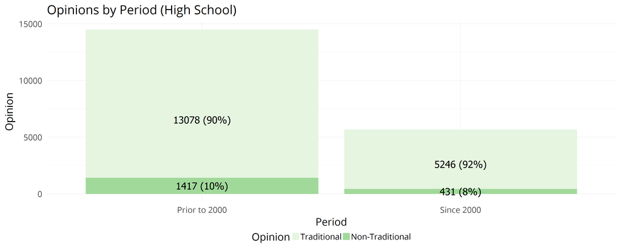

Figure 13: Observed opinions of high school graduates prior to and since the year 2000

As indicated in Figure 13 and Table 18, the observed frequency of traditional opinion since 2,000 in the high school graduate was 5,246 out of a total of 5,677 observations, yielding a proportion equal to 0.92. The observed frequency of traditional opinion prior to 2,000 in the high school graduate population was 13,078 out of a total of 14,495 observations, yielding a proportion equal to 0.9. The difference in observed proportions of traditional opinion was 0.02, raising a z-score of 4.83. The probability of encountering a difference in proportions this extreme (p-value) is approximately 0.

Table 18: Two-proportion z-test of traditional opinion by period for high school graduates

| Test | Groups | Scope | H0 | Ha | Alpha | p1 | p2 | Diff | zScore | pValue | CI | Decision |
| --- | --- | --- | --- | --- | --- | --- | --- | --- | --- | --- | --- | --- |
| Two-Sample Proportion Test | Prior to 2000/Since 2000 | High School Graduate | H0: p1 = p2 | p1 <> p2 | 0.05 | 0.9 | 0.92 | 0.02 | 4.83 | 0 | [ -0.03 , -0.013 ] | Reject |

Therefore, the null hypothesis was rejected with, 95% confidence, in favor of the alternative hypothesis that the true population proportion of traditional opinion within the high school graduate population since 2,000 is not equal to the true population proportion of traditional opinion within the high school graduate population prior to 2,000. Moreover, one can conclude with 95% confidence, that a randomly selected person from the high school graduate population since 2,000 is 1.02 times as likely to hold traditional opinions than such a randomly selected person from the high school graduate population prior to 2,000.

#### Community College

The following hypotheses were devised to ascertain the difference in proportion of traditional opinion w.r.t. extra-marital conduct among those who have attended some college or have earned an associates or technical degree, for the two periods of the study.  
$H_0$ $p_1 - p_2 = 0$  
$H_a$ $p_1 - p_2 \neq 0$  
where:  
$p_1$ is the proportion of traditional opinion among those who have attended some college or have earned an associates or technical degree, for years prior to 2000  
$p_2$ is the proportion of traditional opinion among those who have attended some college or have earned an associates or technical degree, for years since 2000

This was a 95% confidence, two-proportion z-test of the null hypothesis that the true population proportion of traditional opinion within the community college graduate population is equal for the periods prior to, and since, the year 2,000.

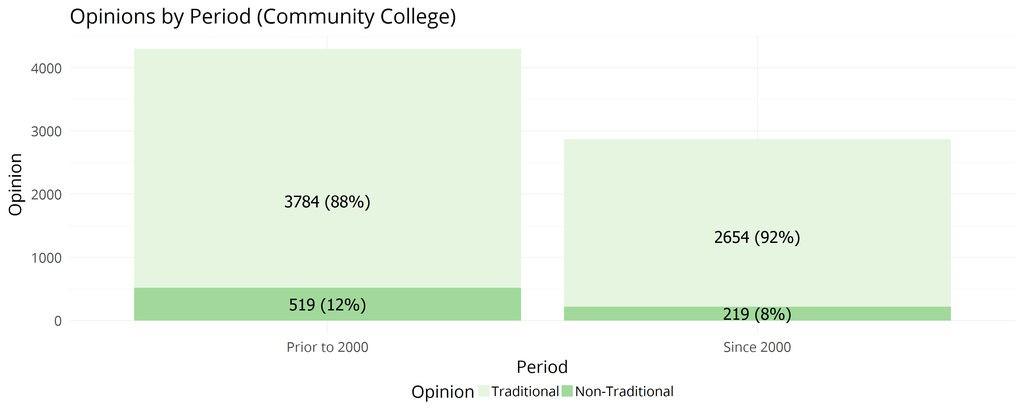

Figure 14: Observed opinions of community graduates prior to and since the year 2000

As indicated in Figure 14 and Table 19, the observed frequency of traditional opinion since 2,000 in the community college graduate was 2,654 out of a total of 2,873 observations, yielding a proportion equal to 0.92. The observed frequency of traditional opinion prior to 2,000 in the community college graduate population was 3,784 out of a total of 4,303 observations, yielding a proportion equal to 0.88. The difference in observed proportions of traditional opinion was 0.04, raising a z-score of 6.07. The probability of encountering a difference in proportions this extreme (p-value) is approximately 0.

Table 19: Two-proportion z-test of traditional opinion among those who have attended some college or have earned an associates or technical degree

| Test | Groups | Scope | H0 | Ha | Alpha | p1 | p2 | Diff | zScore | pValue | CI | Decision |
| --- | --- | --- | --- | --- | --- | --- | --- | --- | --- | --- | --- | --- |
| Two-Sample Proportion Test | Prior to 2000/Since 2000 | Community College Graduate | H0: p1 = p2 | p1 <> p2 | 0.05 | 0.88 | 0.92 | 0.04 | 6.07 | 0 | [ -0.058 , -0.031 ] | Reject |

Therefore, the null hypothesis was rejected with, 95% confidence, in favor of the alternative hypothesis that the true population proportion of traditional opinion within the community college graduate population since 2,000 is not equal to the true population proportion of traditional opinion within the community college graduate population prior to 2,000. Moreover, one can conclude with 95% confidence, that a randomly selected person from the community college graduate population since 2,000 is 1.05 times as likely to hold traditional opinions than such a randomly selected person from the community college graduate population prior to 2,000.

#### UnderGraduate

The following hypotheses were devised to ascertain the difference in proportion of traditional opinion w.r.t. extra-marital conduct among undergraduates for the two periods of the study.  
$H_0$ $p_1 - p_2 = 0$  
$H_a$ $p_1 - p_2 \neq 0$  
where:  
$p_1$ is the proportion of traditional opinion among undergraduates for years prior to 2000  
$p_2$ is the proportion of traditional opinion among undergraduates for years since 2000

This was a 95% confidence, two-proportion z-test of the null hypothesis that the true population proportion of traditional opinion within the undergraduate population is equal for the periods prior to, and since, the year 2,000.

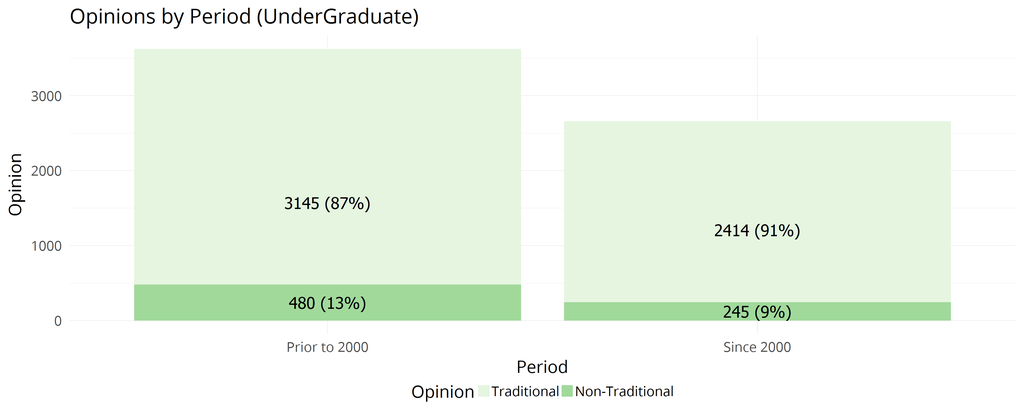

Figure 15: Observed opinions of undergraduates prior to and since the year 2000

As indicated in Figure 15 and Table 20, the observed frequency of traditional opinion since 2,000 in the undergraduate was 2,414 out of a total of 2,659 observations, yielding a proportion equal to 0.91. The observed frequency of traditional opinion prior to 2,000 in the undergraduate population was 3,145 out of a total of 3,625 observations, yielding a proportion equal to 0.87. The difference in observed proportions of traditional opinion was 0.04, raising a z-score of 4.94. The probability of encountering a difference in proportions this extreme (p-value) is approximately 0.

Table 20: Two-proportion z-test of traditional opinion among undergraduates for the two periods of the study.

| Test | Groups | Scope | H0 | Ha | Alpha | p1 | p2 | Diff | zScore | pValue | CI | Decision |
| --- | --- | --- | --- | --- | --- | --- | --- | --- | --- | --- | --- | --- |
| Two-Sample Proportion Test | Prior to 2000/Since 2000 | UnderGraduate | H0: p1 = p2 | p1 <> p2 | 0.05 | 0.87 | 0.91 | 0.04 | 4.94 | 0 | [ -0.056 , -0.025 ] | Reject |

Therefore, the null hypothesis was rejected with, 95% confidence, in favor of the alternative hypothesis that the true population proportion of traditional opinion within the undergraduate population since 2,000 is not equal to the true population proportion of traditional opinion within the undergraduate population prior to 2,000. Moreover, one can conclude with 95% confidence, that a randomly selected person from the undergraduate population since 2,000 is 1.05 times as likely to hold traditional opinions than such a randomly selected person from the undergraduate population prior to 2,000.

#### Graduate

The following hypotheses were devised to ascertain the difference in proportion of traditional opinion w.r.t. extra-marital conduct among those holding graduate degrees, for the two periods of the study.  
$H_0$ $p_1 - p_2 = 0$  
$H_a$ $p_1 - p_2 \neq 0$  
where:  
$p_1$ is the proportion of traditional opinion among those holding graduate degrees, for years prior to 2000  
$p_2$ is the proportion of traditional opinion among those holding graduate degrees, for years since 2000

This was a 95% confidence, two-proportion z-test of the null hypothesis that the true population proportion of traditional opinion within the graduate population is equal for the periods prior to, and since, the year 2,000.

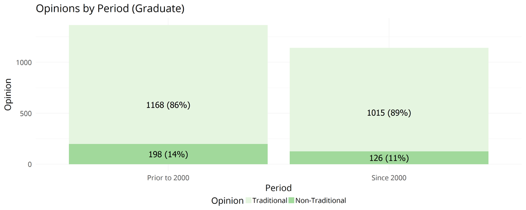

Figure 16: Observed opinions of graduates prior to and since the year 2000

As indicated in Figure 16 and Table 21, the observed frequency of traditional opinion since 2,000 in the graduate was 1,015 out of a total of 1,141 observations, yielding a proportion equal to 0.89. The observed frequency of traditional opinion prior to 2,000 in the graduate population was 1,168 out of a total of 1,366 observations, yielding a proportion equal to 0.86. The difference in observed proportions of traditional opinion was 0.03, raising a z-score of 2.57. The probability of encountering a difference in proportions this extreme (p-value) is approximately 0.0,103.

Table 21: Two-proportion z-test of traditional opinion by period among those holding graduate degrees

| Test | Groups | Scope | H0 | Ha | Alpha | p1 | p2 | Diff | zScore | pValue | CI | Decision |
| --- | --- | --- | --- | --- | --- | --- | --- | --- | --- | --- | --- | --- |
| Two-Sample Proportion Test | Prior to 2000/Since 2000 | Graduate | H0: p1 = p2 | p1 <> p2 | 0.05 | 0.86 | 0.89 | 0.03 | 2.57 | 0.0103 | [ -0.061 , -0.008 ] | Reject |

Therefore, the null hypothesis was rejected with, 95% confidence, in favor of the alternative hypothesis that the true population proportion of traditional opinion within the graduate population since 2,000 is not equal to the true population proportion of traditional opinion within the graduate population prior to 2,000. Moreover, one can conclude with 95% confidence, that a randomly selected person from the graduate population since 2,000 is 1.04 times as likely to hold traditional opinions than such a randomly selected person from the graduate population prior to 2,000.

#### Post-Graduate

The following hypotheses were devised to ascertain the difference in proportion of traditional opinion w.r.t. extra-marital conduct among those holding post-graduate degrees, for the two periods of the study.  
$H_0$ $p_1 - p_2 = 0$  
$H_a$ $p_1 - p_2 \neq 0$  
where:  
$p_1$ is the proportion of traditional opinion among those holding post-graduate degrees, for years prior to 2000  
$p_2$ is the proportion of traditional opinion among those holding post-graduate degrees, for years since 2000

This was a 95% confidence, two-proportion z-test of the null hypothesis that the true population proportion of traditional opinion within the post-graduate population is equal for the periods prior to, and since, the year 2,000.

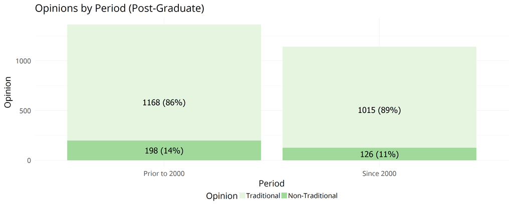

Figure 17: Observed opinions of post-graduates prior to and since the year 2000

Table 22: Two-proportion z-test of traditional opinion by period among those holding post-graduate degrees

| Test | Groups | Scope | H0 | Ha | Alpha | p1 | p2 | Diff | zScore | pValue | CI | Decision |
| --- | --- | --- | --- | --- | --- | --- | --- | --- | --- | --- | --- | --- |
| Two-Sample Proportion Test | Prior to 2000/Since 2000 | Post-Graduate | H0: p1 = p2 | p1 <> p2 | 0.05 | 0.86 | 0.89 | 0.03 | 2.57 | 0.0103 | [ -0.061 , -0.008 ] | Reject |

Therefore, the null hypothesis was rejected with, 95% confidence, in favor of the alternative hypothesis that the true population proportion of traditional opinion within the post-graduate population since 2,000 is not equal to the true population proportion of traditional opinion within the post-graduate population prior to 2,000. Moreover, one can conclude with 95% confidence, that a randomly selected person from the post-graduate population since 2,000 is 1.04 times as likely to hold traditional opinions than such a randomly selected person from the post-graduate population prior to 2,000.

## Research Question 4: Evolution of opinion by region

Here, the degree to which opinions w.r.t. extra-marital conduct have changed by region was examined via the following research question.

> To what degree have opinions changed since the year 2000 by geographic region?

### Hypotheses

The following hypotheses were tested to discover the extent to which opinion has changed by region level, over the periods of the study. Generally stated, they are: $H_0$ $p_1 - p_2 = 0$  
$H_a$ $p_1 - p_2 \neq 0$

where:  
$p_1$ is the proportion of traditional opinion by region for years prior to 2000  
$p_2$ is the proportion of traditional opinion by region for years since 2000

The specific hypotheses for each region are stated below.

### Inference Conditions

The inference conditions for a two-proportion test for differences in the proportion of traditional opinion at various region levels, were examined as follows:

1. **Independence:** Each observation was subject to a stratified random sampling and so **independence** was assumed.
2. **Success/Failure:** Expected counts for each response/explanatory/controlling variable combination must be five or greater. As shown in Table 23, the expected counts exceed this minimum threshold.
3. **Sample Size:** As indicated in section the methods section, the sample size falls well below 10% of the U.S. adult population.

Table 23: Contingency table of expected counts of opinions by region, controlling for period

|  |  | Region | Northeast | South | Midwest | Mountain | Pacific |
| --- | --- | --- | --- | --- | --- | --- | --- |
| Opinion | Period |  |  |  |  |  |  |
| Traditional | Prior to 2000 |  | 4149 | 7727 | 5650 | 1352 | 2927 |
|  | Since 2000 |  | 2267 | 4222 | 3087 | 739 | 1599 |
| Non-Traditional | Prior to 2000 |  | 523 | 974 | 712 | 170 | 369 |
|  | Since 2000 |  | 213 | 396 | 289 | 69 | 150 |

As such, the conditions for two-proportion z-tests were met.

### Test Results

#### Northeast Region

The following hypotheses were devised to ascertain the difference in proportion of traditional opinion w.r.t. extra-marital conduct in the Northeast region, for the two periods of the study.  
$H_0$ $p_1 - p_2 = 0$  
$H_a$ $p_1 - p_2 \neq 0$  
where:  
$p_1$ is the proportion of traditional opinion in the Northeast region, for years prior to 2000  
$p_2$ is the proportion of traditional opinion in the Northeast region, for years since 2000

This was a 95% confidence, two-proportion z-test of the null hypothesis that the true population proportion of traditional opinion within the northeast region population is equal for the periods prior to, and since, the year 2,000.

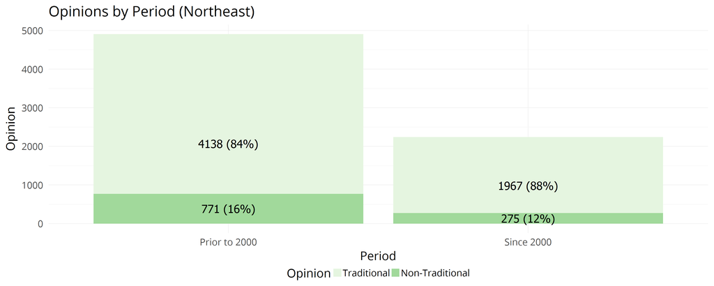

Figure 18: Observed opinions from the Northeast region for periods prior to and since 2000

As indicated in Figure 18 and Table 24, the observed frequency of traditional opinion since 2,000 in the northeast region was 1,967 out of a total of 2,242 observations, yielding a proportion equal to 0.88. The observed frequency of traditional opinion prior to 2,000 in the northeast region population was 4,138 out of a total of 4,909 observations, yielding a proportion equal to 0.84. The difference in observed proportions of traditional opinion was 0.03, raising a z-score of 3.82. The probability of encountering a difference in proportions this extreme (p-value) is approximately 0.0,001.

Table 24: Two-proportion z-test of traditional opinion in the Northeast region, for the two periods of the study.

| Test | Groups | Scope | H0 | Ha | Alpha | p1 | p2 | Diff | zScore | pValue | CI | Decision |
| --- | --- | --- | --- | --- | --- | --- | --- | --- | --- | --- | --- | --- |
| Two-Sample Proportion Test | Prior to 2000/Since 2000 | Northeast Region | H0: p1 = p2 | p1 <> p2 | 0.05 | 0.84 | 0.88 | 0.03 | 3.82 | 0.0001 | [ -0.051 , -0.017 ] | Reject |

Therefore, the null hypothesis was rejected with, 95% confidence, in favor of the alternative hypothesis that the true population proportion of traditional opinion within the northeast region population since 2,000 is not equal to the true population proportion of traditional opinion within the northeast region population prior to 2,000. Moreover, one can conclude with 95% confidence, that a randomly selected person from the northeast region population since 2,000 is 1.04 times as likely to hold traditional opinions than such a randomly selected person from the northeast region population prior to 2,000.

#### South Region

The following hypotheses were devised to ascertain the difference in proportion of traditional opinion w.r.t. extra-marital conduct in the South region, for the two periods of the study.  
$H_0$ $p_1 - p_2 = 0$  
$H_a$ $p_1 - p_2 \neq 0$  
where:  
$p_1$ is the proportion of traditional opinion in the South region, for years prior to 2000  
$p_2$ is the proportion of traditional opinion in the South region, for years since 2000

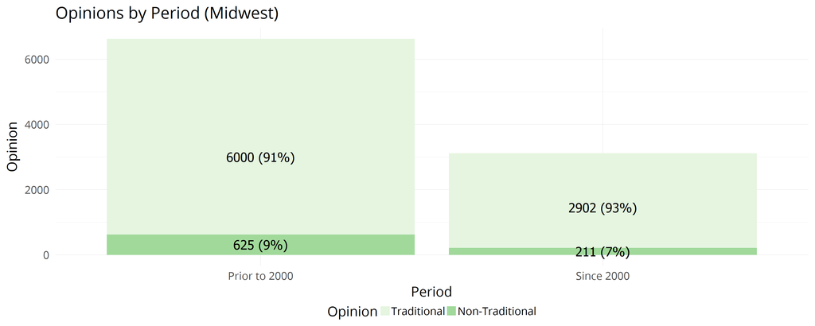

As indicated in Figure 19 and Table 25, the observed frequency of traditional opinion since 2,000 in the midwest region was 2,902 out of a total of 3,113 observations, yielding a proportion equal to 0.93. The observed frequency of traditional opinion prior to 2,000 in the midwest region population was 6,000 out of a total of 6,625 observations, yielding a proportion equal to 0.91. The difference in observed proportions of traditional opinion was 0.03, raising a z-score of 4.36. The probability of encountering a difference in proportions this extreme (p-value) is approximately 0.

| Test | Groups | Scope | H0 | Ha | Alpha | p1 | p2 | Diff | zScore | pValue | CI | Decision |
| --- | --- | --- | --- | --- | --- | --- | --- | --- | --- | --- | --- | --- |
| Two-Sample Proportion Test | Prior to 2000/Since 2000 | Midwest Region | H0: p1 = p2 | p1 <> p2 | 0.05 | 0.91 | 0.93 | 0.03 | 4.36 | 0 | [ -0.038 , -0.015 ] | Reject |

Therefore, the null hypothesis was rejected with, 95% confidence, in favor of the alternative hypothesis that the true population proportion of traditional opinion within the midwest region population since 2,000 is not equal to the true population proportion of traditional opinion within the midwest region population prior to 2,000. Moreover, one can conclude with 95% confidence, that a randomly selected person from the midwest region population since 2,000 is 1.03 times as likely to hold traditional opinions than such a randomly selected person from the midwest region population prior to 2,000.

#### Midwest Region

The following hypotheses were devised to ascertain the difference in proportion of traditional opinion in the Midwest region, for the two periods of the study.  
$H_0$ $p_1 - p_2 = 0$  
$H_a$ $p_1 - p_2 \neq 0$  
where:  
$p_1$ is the proportion of traditional opinion in the Midwest region, for years prior to 2000  
$p_2$ is the proportion of traditional opinion in the Midwest region, for years since 2000

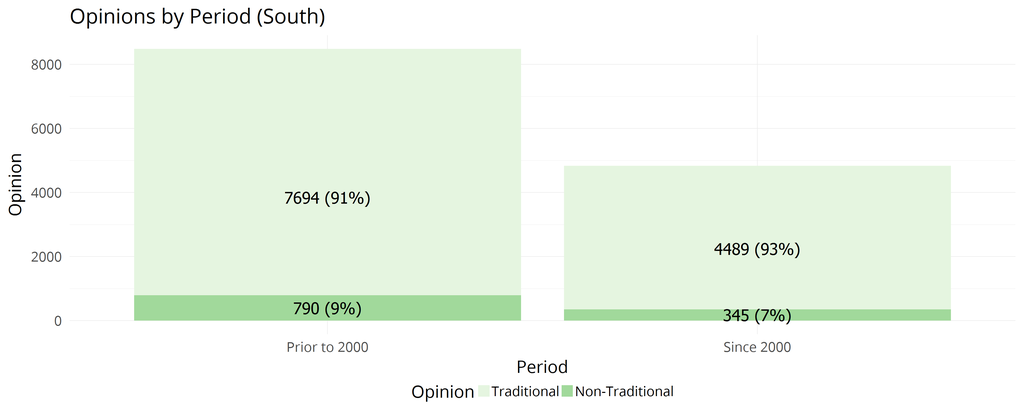

As indicated in Figure 20 and Table 26, the observed frequency of traditional opinion since 2,000 in the south region was 4,489 out of a total of 4,834 observations, yielding a proportion equal to 0.93. The observed frequency of traditional opinion prior to 2,000 in the south region population was 7,694 out of a total of 8,484 observations, yielding a proportion equal to 0.91. The difference in observed proportions of traditional opinion was 0.02, raising a z-score of 4.32. The probability of encountering a difference in proportions this extreme (p-value) is approximately 0.

| Test | Groups | Scope | H0 | Ha | Alpha | p1 | p2 | Diff | zScore | pValue | CI | Decision |
| --- | --- | --- | --- | --- | --- | --- | --- | --- | --- | --- | --- | --- |
| Two-Sample Proportion Test | Prior to 2000/Since 2000 | South Region | H0: p1 = p2 | p1 <> p2 | 0.05 | 0.91 | 0.93 | 0.02 | 4.32 | 0 | [ -0.031 , -0.012 ] | Reject |

Therefore, the null hypothesis was rejected with, 95% confidence, in favor of the alternative hypothesis that the true population proportion of traditional opinion within the south region population since 2,000 is not equal to the true population proportion of traditional opinion within the south region population prior to 2,000. Moreover, one can conclude with 95% confidence, that a randomly selected person from the south region population since 2,000 is 1.02 times as likely to hold traditional opinions than such a randomly selected person from the south region population prior to 2,000.

#### Mountain Region

The following hypotheses were devised to ascertain the difference in proportion of traditional opinion w.r.t. extra-marital conduct in the Mountain region, for the two periods of the study.  
$H_0$ $p_1 - p_2 = 0$  
$H_a$ $p_1 - p_2 \neq 0$  
where:  
$p_1$ is the proportion of traditional opinion in the Mountain region, for years prior to 2000  
$p_2$ is the proportion of traditional opinion in the Mountain region, for years since 2000

This was a 95% confidence, two-proportion z-test of the null hypothesis that the true population proportion of traditional opinion within the mountain region population is equal for the periods prior to, and since, the year 2,000.

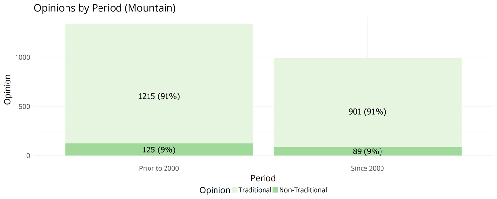

Figure 21: Observed opinions from the Mountain region for periods prior to and since 2000

As indicated in Figure 21 and Table 27, the observed frequency of traditional opinion since 2,000 in the mountain region was 901 out of a total of 990 observations, yielding a proportion equal to 0.91. The observed frequency of traditional opinion prior to 2,000 in the mountain region population was 1,215 out of a total of 1,340 observations, yielding a proportion equal to 0.91. The difference in observed proportions of traditional opinion was 0, raising a z-score of 0.28. The probability of encountering a difference in proportions this extreme (p-value) is approximately 0.7,798.

Table 27: Two-proportion z-test of traditional opinion by period in the Mountain region

| Test | Groups | Scope | H0 | Ha | Alpha | p1 | p2 | Diff | zScore | pValue | CI | Decision |
| --- | --- | --- | --- | --- | --- | --- | --- | --- | --- | --- | --- | --- |
| Two-Sample Proportion Test | Prior to 2000/Since 2000 | Mountain Region | H0: p1 = p2 | p1 <> p2 | 0.05 | 0.91 | 0.91 | 0 | 0.28 | 0.7798 | [ -0.027 , 0.02 ] | Fail to Reject |

Therefore, the null hypothesis was not rejected; consequently, one concludes, with 95% confidence, that the true proportion of traditional opinion among the mountain region population prior to and since the year 2,000 are equal. Further, the confidence interval for the difference in proportions includes zero, the null hypothesis value. As such, the null hypothesis is not rejected and both the hypothesis test and confidence interval methods agree.

#### Pacific Region

The following hypotheses were devised to ascertain the difference in proportion of traditional opinion w.r.t. extra-marital conduct in the Pacific region, for the two periods of the study.  
$H_0$ $p_1 - p_2 = 0$  
$H_a$ $p_1 - p_2 \neq 0$  
where:  
$p_1$ is the proportion of traditional opinion in the Pacific region, for years prior to 2000  
$p_2$ is the proportion of traditional opinion in the Pacific region, for years since 2000

This was a 95% confidence, two-proportion z-test of the null hypothesis that the true population proportion of traditional opinion within the pacific region population is equal for the periods prior to, and since, the year 2,000.

[figure not shown]

Figure 22: Observed opinions from the Pacific region for periods prior to and since 2000

Table 28: Two-proportion z-test of traditional opinion by period in the Pacific region

[output not shown]

Therefore, the null hypothesis was not rejected; consequently, one concludes, with 95% confidence, that the true proportion of traditional opinion among the pacific region population prior to and since the year 2,000 are equal. Further, the confidence interval for the difference in proportions includes zero, the null hypothesis value. As such, the null hypothesis is not rejected and both the hypothesis test and confidence interval methods agree.

# Discussion

## Evolution of Opinion by Age Group

[output not shown]

[output not shown]

% change within the 65+ age group was not significant.

Table 29: Summary of analysis by age group

| Scope | p1 | p2 | PctChange | Significant |
| --- | --- | --- | --- | --- |
| Age Group 15-24 | 0.85 | 0.91 | 5.88 | Yes |
| Age Group 25-45 | 0.87 | 0.91 | 4.60 | Yes |
| Age Group 45-65 | 0.90 | 0.91 | 1.11 | Yes |
| Age Group 65+ | 0.94 | 0.93 | 1.06 | No |

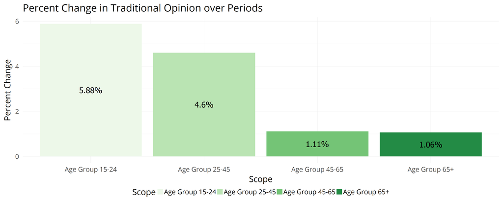

Figure 23: Summary of analysis by age group

## Evolution of Opinion by Gender

Similarly, there was a trend towards more traditional opinion for both males and females, with

[output not shown]

[output not shown]

% increases respectively. As indicated in Figure 24, the migration towards more traditional views was most pronounced among men.

Table 30: Summary of analysis by gender

| Scope | p1 | p2 | PctChange | Significant |
| --- | --- | --- | --- | --- |
| Male | 0.86 | 0.90 | 4.65 | Yes |
| Female | 0.91 | 0.93 | 2.20 | Yes |

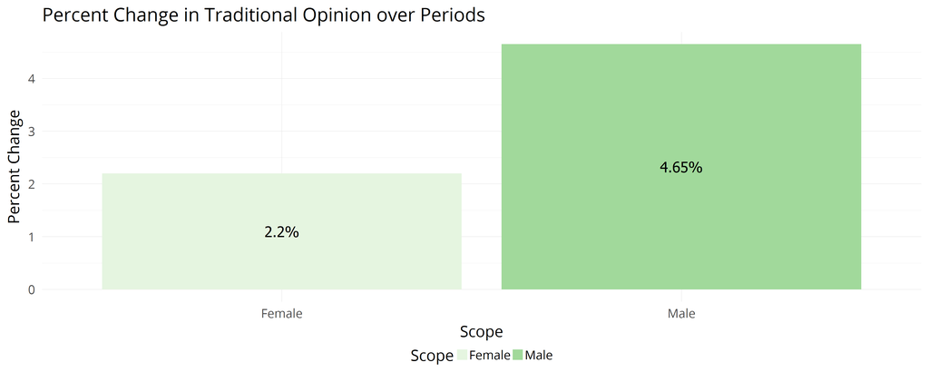

Figure 24: Summary of analysis by gender

## Evolution of Opinion by Education Level

[output not shown]

[output not shown]

Table 31: Summary of analysis by education level

| Scope | p1 | p2 | PctChange | Significant |
| --- | --- | --- | --- | --- |
| UnderGraduate | 0.87 | 0.91 | 4.60 | Yes |
| Community College Graduate | 0.88 | 0.92 | 4.55 | Yes |
| Graduate | 0.86 | 0.89 | 3.49 | Yes |
| Post-Graduate | 0.86 | 0.89 | 3.49 | Yes |
| High School Graduate | 0.90 | 0.92 | 2.22 | Yes |

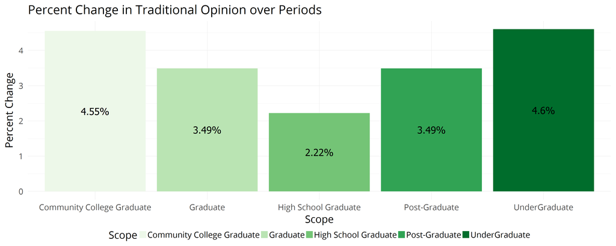

Figure 25: Summary of analysis by education level